# Advanced Machine Learning Group Assignment 3

Team U

12/03/2018

```r
library(R.matlab)
data = readMat("olivettifaces.mat")  # Have it as a .mat file
faces = data$faces
dim(faces)
```

```
## [1] 4096  400
```

```r
NumFaces = length(faces[1,])
NumPixels = length(faces[,1])
```

```r
NumFacesPCA = 400;  # Number of images we will use for PCA
set.seed(1)
index = sample(1:NumFaces, NumFacesPCA);
TrainImages = faces[,index]
```

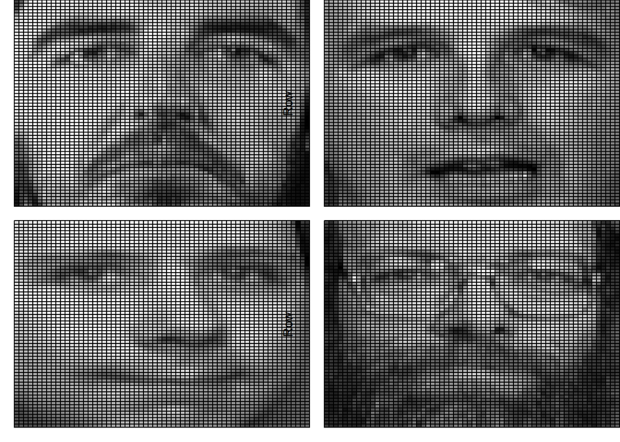

```r
library(plotrix)
n = 2
par(mfrow = c(n,n),     # 2x2 layout
    oma = c(0, 0, 0, 0), # controls rows for text at outer  margins
    mar = c(1, 1, 0, 0), # space for one row of text at ticks and to separate plots
    mgp = c(2, 1, 0),    # axis label at 2 rows distance, tick labels at 1 row
    xpd = NA)
for (i in 1:n^2){
  Face = matrix(TrainImages[,i],sqrt(NumPixels),byrow=FALSE)
  color2D.matplot(Face,axes=FALSE)
}
```

Let’s compute the mean face and plot it.

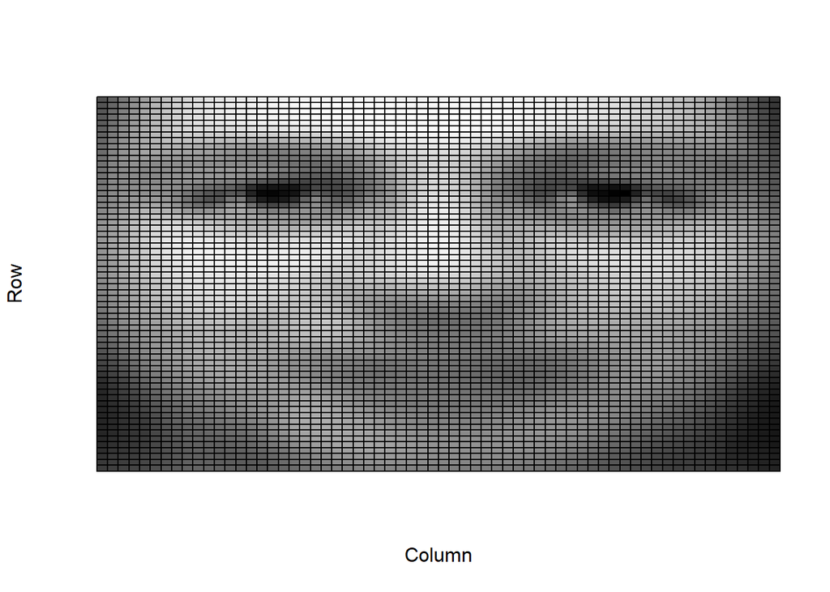

```r
mean_image = apply(TrainImages, 1, mean)
mean_Face = matrix(mean_image,sqrt(NumPixels),byrow=FALSE)
color2D.matplot(mean_Face,axes=FALSE)
```

##Answer:

The mathematical expression of how we construct the approximaiton:

$x_{ij}=(\sum^M_{m=1}z_{im}\phi_{jm})\cdot sdev(x_j) + mean(x_j)$ , where M is the number of principle component we choose. $sdev(x_j)$ is the standard deviation of the $x_j$ column, and $mean(x_j)$ is the original mean of the $x_j$ column.

```r
pr.out <- prcomp(TrainImages, scale = TRUE)# scale = True scale the variables have standard variation one. Default centers the variabls to have mean zero
dim(pr.out$rotation)
```

```
## [1] 400 400
```

```r
dim(pr.out$x)
```

```
## [1] 4096  400
```

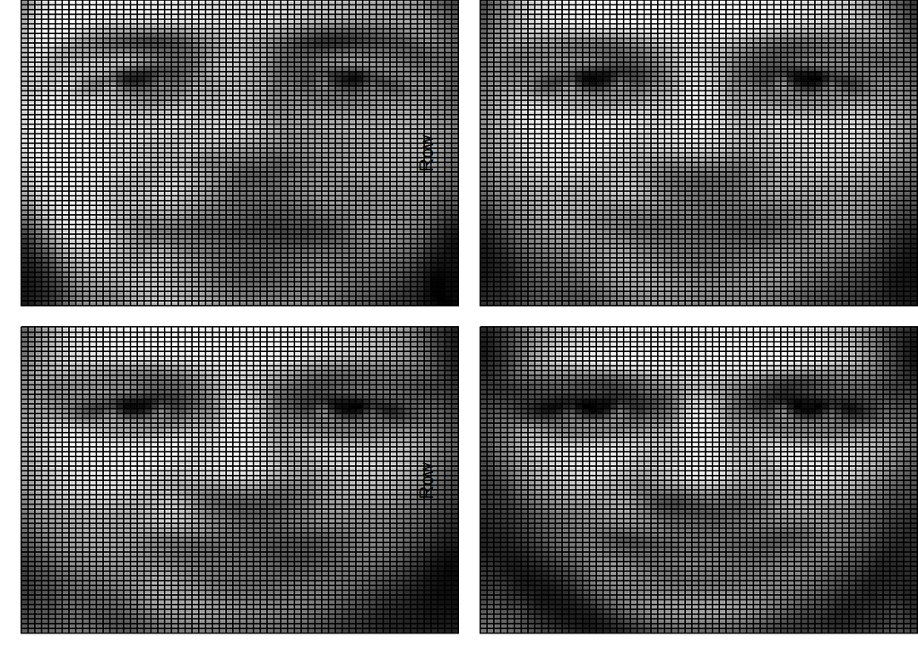

```r
k <-3
pc <-pr.out$x[, 1:k]
loading <- t(pr.out$rotation[ , 1:k])

approx_x <- pc %*% loading

#unscale and uncenter the data
if(pr.out$scale !=FALSE){
  approx_x <- scale(approx_x, center = FALSE, scale = 1/pr.out$scale)
}

if(all(pr.out$center != FALSE)){
  approx_x <-scale(approx_x, center = -1*pr.out$center, scale = FALSE)
}

n = 2
par(mfrow = c(n,n),     # 2x2 layout
    oma = c(0, 0, 0, 0), # controls rows for text at outer  margins
    mar = c(1, 1, 0, 0), # space for one row of text at ticks and to separate plots
    mgp = c(2, 1, 0),    # axis label at 2 rows distance, tick labels at 1 row
    xpd = NA)
for (i in 1:n^2){
  Face = matrix(approx_x[,i],sqrt(NumPixels),byrow=FALSE)
  color2D.matplot(Face,axes=FALSE)
}
```

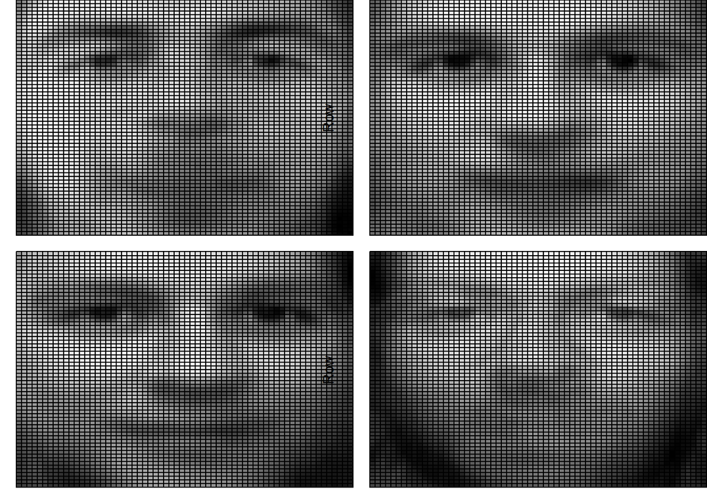

```r
k <-10
pc <-pr.out$x[, 1:k]
loading <- t(pr.out$rotation[ , 1:k])

approx_x <- pc %*% loading
#unscale and uncenter the data
if(pr.out$scale !=FALSE){
  approx_x <- scale(approx_x, center = FALSE, scale = 1/pr.out$scale)
}

if(all(pr.out$center != FALSE)){
  approx_x <-scale(approx_x, center = -1*pr.out$center, scale = FALSE)
}

n = 2
par(mfrow = c(n,n),     # 2x2 layout
    oma = c(0, 0, 0, 0), # controls rows for text at outer  margins
    mar = c(1, 1, 0, 0), # space for one row of text at ticks and to separate plots
    mgp = c(2, 1, 0),    # axis label at 2 rows distance, tick labels at 1 row
    xpd = NA)
for (i in 1:n^2){
  Face = matrix(approx_x[,i],sqrt(NumPixels),byrow=FALSE)
  color2D.matplot(Face,axes=FALSE)
}
```

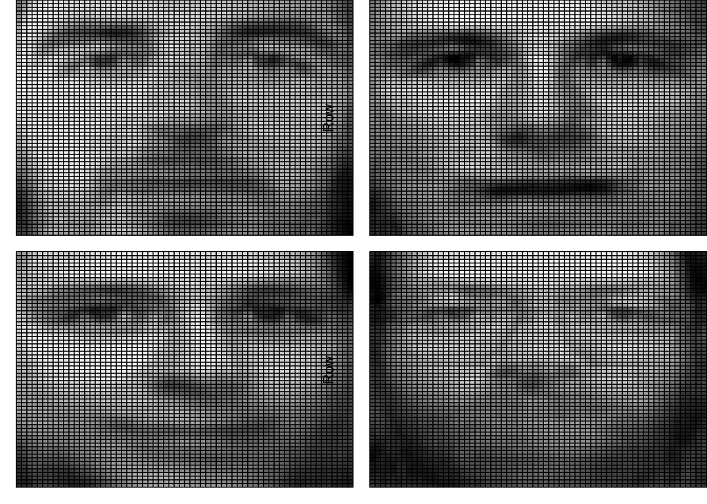

```r
k <-25
pc <-pr.out$x[, 1:k]
loading <- t(pr.out$rotation[ , 1:k])

approx_x <- pc %*% loading
#unscale and uncenter the data
if(pr.out$scale !=FALSE){
  approx_x <- scale(approx_x, center = FALSE, scale = 1/pr.out$scale)
}

if(all(pr.out$center != FALSE)){
  approx_x <-scale(approx_x, center = -1*pr.out$center, scale = FALSE)
}

n = 2
par(mfrow = c(n,n),     # 2x2 layout
    oma = c(0, 0, 0, 0), # controls rows for text at outer  margins
    mar = c(1, 1, 0, 0), # space for one row of text at ticks and to separate plots
    mgp = c(2, 1, 0),    # axis label at 2 rows distance, tick labels at 1 row
    xpd = NA)
for (i in 1:n^2){
  Face = matrix(approx_x[,i],sqrt(NumPixels),byrow=FALSE)
  color2D.matplot(Face,axes=FALSE)
}
```

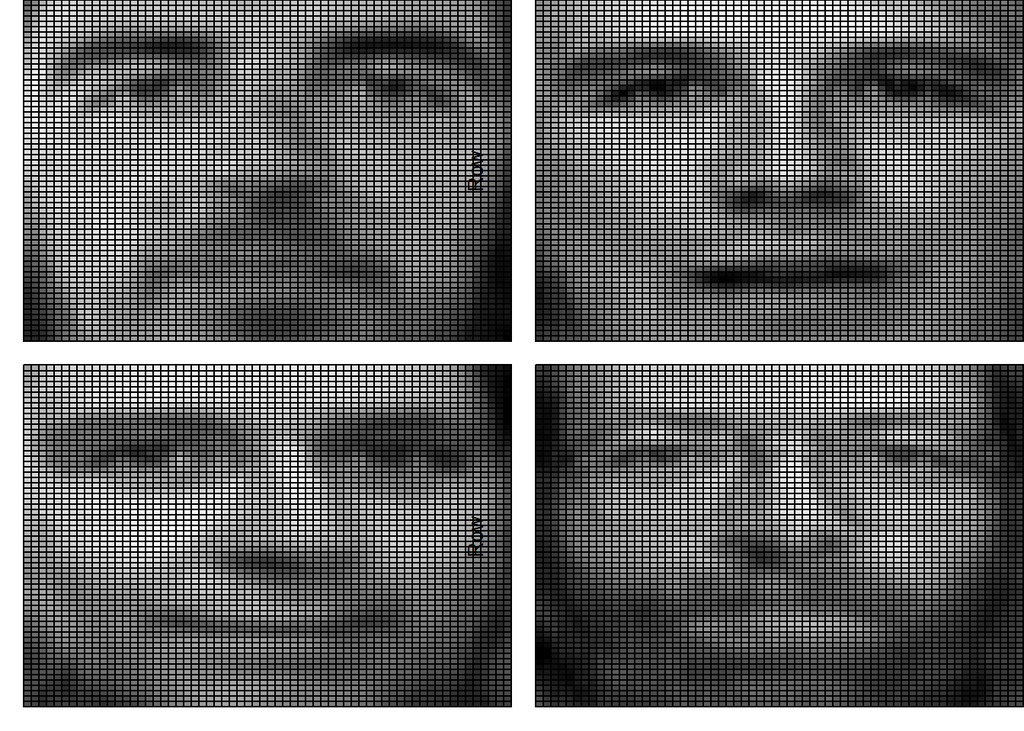

```r
k <-50
pc <-pr.out$x[, 1:k]
loading <- t(pr.out$rotation[ , 1:k])

approx_x <- pc %*% loading
#unscale and uncenter the data
if(pr.out$scale !=FALSE){
  approx_x <- scale(approx_x, center = FALSE, scale = 1/pr.out$scale)
}

if(all(pr.out$center != FALSE)){
  approx_x <-scale(approx_x, center = -1*pr.out$center, scale = FALSE)
}

n = 2
par(mfrow = c(n,n),     # 2x2 layout
    oma = c(0, 0, 0, 0), # controls rows for text at outer  margins
    mar = c(1, 1, 0, 0), # space for one row of text at ticks and to separate plots
    mgp = c(2, 1, 0),    # axis label at 2 rows distance, tick labels at 1 row
    xpd = NA)
for (i in 1:n^2){
  Face = matrix(approx_x[,i],sqrt(NumPixels),byrow=FALSE)
  color2D.matplot(Face,axes=FALSE)
}
```

Q2 a)Generate a simulated data set with 20 observations in each of three classes (i.e. 60 observations total), and 50 variables.

```r
set.seed(1)
x <- matrix(rnorm(60*50), ncol = 50)
x[1:20,1:12] <- x[1:20, 1:12] +0.6 #mean shift for the first 12 variables for class 1
x[1:20,13:50] <- x[1:20,13:50] -0.6 #mean shift for the other 38 variables for class 1

x[21:40, 1:30] <- x[21:40, 1:30] -0.8#mean shift for the first 30 variables for calss 2
x[21:40, 31:50] <- x[21:40, 31:50] + 0.8#mean shift for the other 20 variables for class 2
#apply(x,2,sd)
```

```r
trueclass <- matrix(rnorm(60*1), ncol = 1)
for (i in 1:nrow(trueclass)){
  if(i<=20){
    trueclass[i,1] <-"1"
  }else if(i>40){
    trueclass[i,1]<- "2"
  }else{
    trueclass[i,1] <-"3"
  }
}
```

2. Perform PCA on the 60 observations and plot the frst two principal component score vectors. Use a different color to indicate the observations in each of the three classes. If the three classes appear separated in this plot, then continue on to part (c). If not, then return to part
3. and modify the simulation so that there is greater separation between the three classes. Do not continue to part (c) until the three classes show at least some separation in the first two principal component score vectors. (10 marks)

```r
pca <-prcomp(x, scale = TRUE)
```

```r
Cols <- function(vec){
  cols <-rainbow(length(unique(vec)))
  return(cols[as.numeric(as.factor(vec))])
}
```

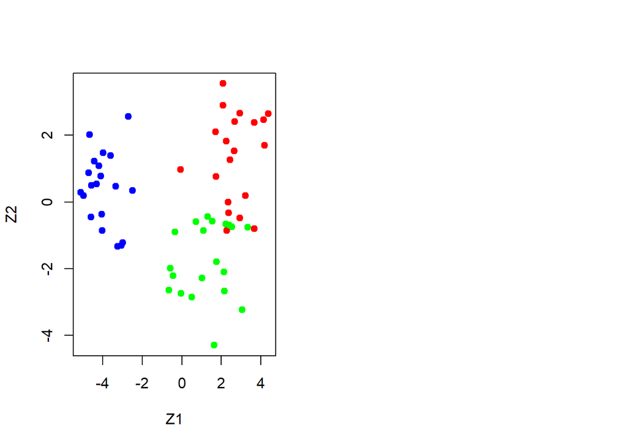

```r
par(mfrow = c(1,2))
plot(pca$x[,1:2], col = Cols(trueclass), pch = 19, xlab = "Z1", ylab = "Z2")
```

3. Perform K-means clustering of the observations with K = 3. How well do the clusters that you obtained in K-means clustering compare to the true class labels? (10 marks)

Answer: The label might be different form the original one, but the accuracy is 1-3/60 = 0.95.

```r
set.seed(1)
three_means<-kmeans(x, 3, nstart = 10)
table(three_means$cluster, trueclass)
```

```
##    trueclass
##      1  2  3
##   1  0  0 20
##   2 19  2  0
##   3  1 18  0
```

4. Perform K-means clustering with K = 2. Describe your results. (5 marks)

Answer: When k = 2, the first two true class are combine to be one class, leaving class 3 as one class.

```r
set.seed(2)
two_means <- kmeans(x, 2, nstart = 10)
table(two_means$cluster, trueclass)
```

```
##    trueclass
##      1  2  3
##   1 20 20  0
##   2  0  0 20
```

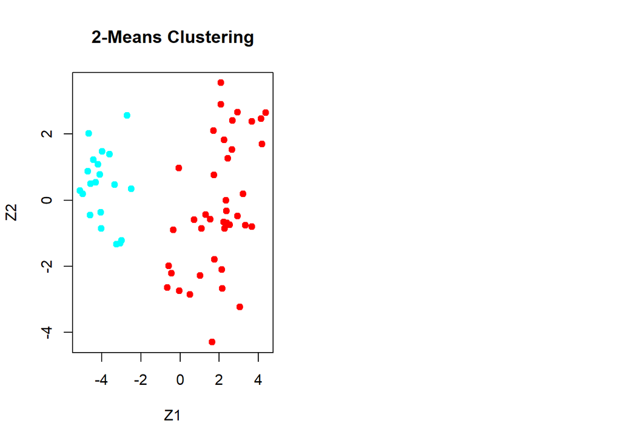

```r
par(mfrow = c(1,2))
plot(pca$x[,1:2], col = Cols(two_means$cluster),main = "2-Means Clustering", pch = 19, xlab = "Z1", ylab = "Z2")
```

5. Now perform K-means clustering with K = 4, and describe your results. (5 marks)

Answer: We can see that there are two classes(2 and 3) mostly correctly assign, while the majority of class 1 is splited into two seperated classes, being clustered into two classes(1 and 4).

```r
set.seed(2)
four_means <- kmeans(x, 4, nstart = 10)
table(four_means$cluster, trueclass)
```

```
##    trueclass
##      1  2  3
##   1 11  2  0
##   2  1 17  0
##   3  0  0 20
##   4  8  1  0
```

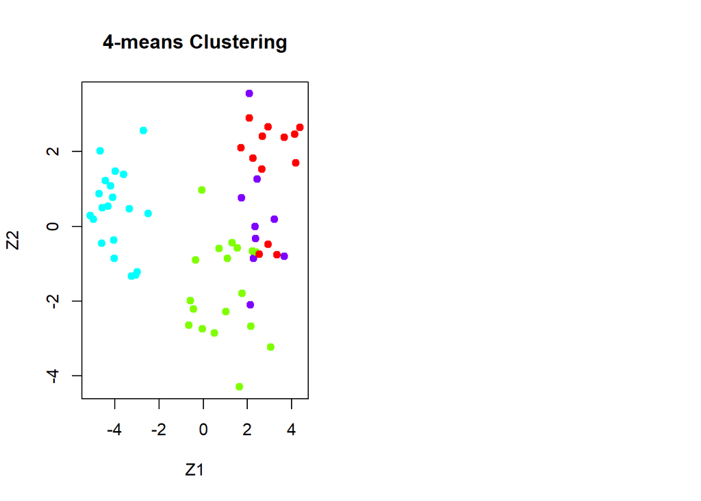

```r
par(mfrow = c(1,2))
plot(pca$x[,1:2], col = Cols(four_means$cluster),main = "4-means Clustering", pch = 19, xlab = "Z1", ylab = "Z2")
```

6. Now perform K-means clustering with K = 3 on the first two principal component score vectors, rather than on the raw data. That is, perform K-means clustering on the 60$$2 matrix of which the first column is the first principal component score vector, and the second column is the second principal component score vector. Comment on the results. (10 marks)

```r
pc2 <-pca$x[,1:2]
three_means_pca <- kmeans(pc2,3, nstart = 10)
table(three_means_pca$cluster, trueclass)
```

```
##    trueclass
##      1  2  3
##   1  0  0 20
##   2 14  0  0
##   3  6 20  0
```

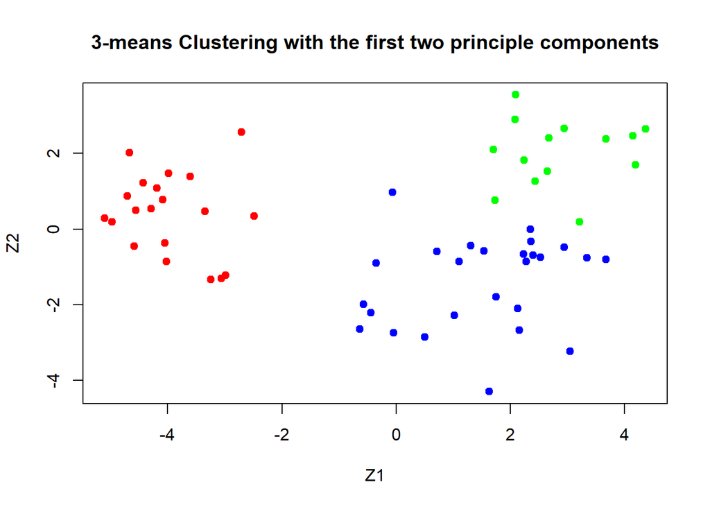

```r
plot(pca$x[,1:2], col = Cols(three_means_pca$cluster),main = "3-means Clustering with the first two principle components", pch = 19, xlab = "Z1", ylab = "Z2")
```

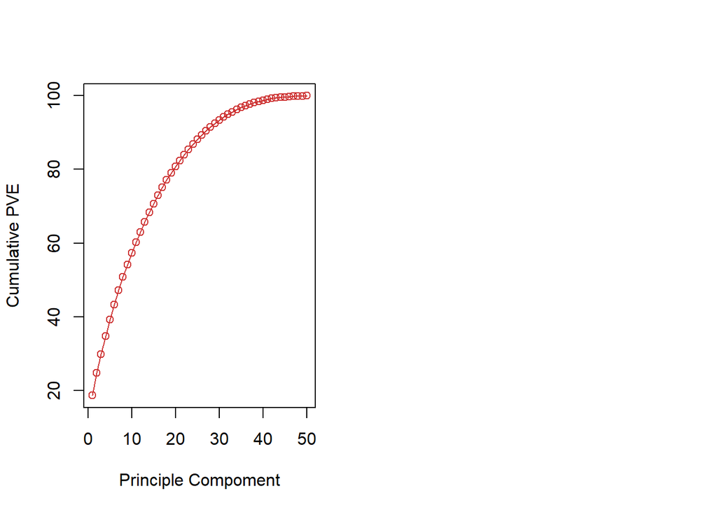

```r
pve <- 100*pca$sdev^2/sum(pca$sdev^2)
par(mfrow = c(1,2))
plot(cumsum(pve), type = "o", ylab = "Cumulative PVE", xlab = "Principle Compoment", col = "brown3")
```

7. Using the scale() function, perform K-means clustering with K = 3 on the data after scaling each variable to have standard deviation one. How do these results compare to those obtained in (b)? Explain. (10 marks)

Answer: After scaling, the accuracy decrease to 1-4/60=0.93. This is due to the scale affecting the distance between the observations.

```r
scale_k_means<- kmeans(scale(x), 3, nstart = 10)
table(scale_k_means$cluster, trueclass)
```

```
##    trueclass
##      1  2  3
##   1  0  0 20
##   2  3 19  0
##   3 17  1  0
```